# Aprendizaje no supervisado

En este notebook se lleva a cabo un análisis no supervisado para dividir en clústeres o subgrafos la red de oncogenes que estamos estudiando. La idea es comparar los datos obtenidos con el aprendizaje no supervisado y el descubrimiento de comunidades. Se aplican dos tipos de clustering: jerárquico y con kmeans.

En primer lugar, cargamos las librerías necesarias.

```r
#install.packages("factoextra")
library(igraph)
library(readxl)
library(factoextra)
library(dplyr)
```

Se carga el grafo

```r
#Cargo datos
aristas <- read_excel("./Dataset1.xlsx",
                    sheet = "WeigthedNetwork")
nodos <- read_excel("./Dataset1.xlsx",
                    sheet = "NetworkNodes")
#Construyo el grafo
grafo_origen <-
  graph_from_data_frame(d = aristas, vertices = nodos,  directed=F)

#Podo cogiendo como umbral 0.4
grafo <- delete_edges(grafo_origen, E(grafo_origen)[PESO<0.4])
```

Cargo el dataframe con las medidas de centralidad, cogiendo solo datos numéricoS, y estandarizo los datos.

```r
df <- read.table("./dataframe.txt", header = TRUE, sep = ",")
grafodf <- df[, 3:6 ]
grafodf$Degree <- scale(grafodf$Degree)
grafodf$Centrality <- scale(grafodf$Centrality)
grafodf$Closeness <- scale(grafodf$Closeness)
grafodf$Betweeness <- scale(grafodf$Betweeness)
grafodf
```

| Degree | Centrality | Closeness | Betweeness |
| --- | --- | --- | --- |
| 0.52868999 | -0.29690296 | 0.35980364 | 0.65349853 |
| 0.40689633 | -0.56858588 | 0.36517934 | 1.44537162 |
| 0.40689633 | -0.29867862 | 0.36195206 | -0.17288070 |
| 0.40689633 | -0.49075547 | 0.36410296 | 0.41648063 |
| 1.66543081 | 1.78978347 | 0.40434582 | 0.70444053 |
| 0.08211324 | -0.66293545 | 0.35337316 | 0.12331785 |
| 0.08211324 | -0.48616820 | 0.36625634 | 1.91522926 |
| 0.04151535 | 0.30007044 | 0.33421384 | -0.55466592 |
| -0.89223604 | -1.01280548 | 0.27277103 | -0.64917815 |
| 0.48809210 | 0.81244035 | 0.34483353 | -0.65306331 |

[output cut: 167 more lines]

```r
NA
```

Generamos la matriz de adyacencia.

```r
matgraf <- get.adjacency(grafo, attr="PESO", sparse=F)
```

ALGORITMO K-MEANS: Matriz de adyacencia

En primer lugar, observamos el valor optimo de k que resulta ser k=4.

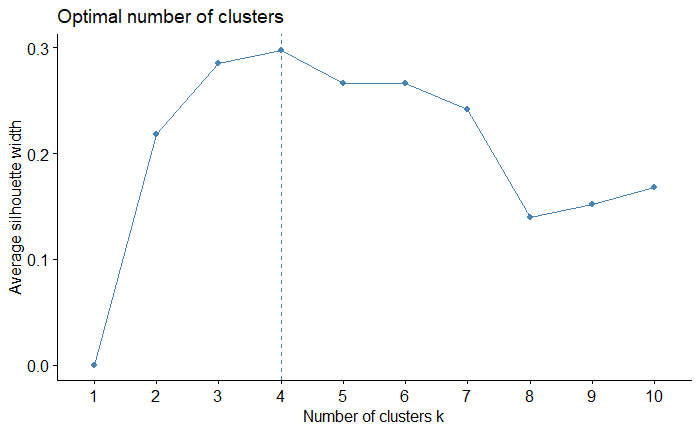

```r
fnb<- fviz_nbclust(matgraf, kmeans, method = "silhouette")
fnb
```

Aplicamos el clustering con kmeans para k=4.

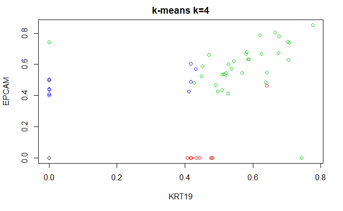

```r
km_grafo <- kmeans(matgraf, centers = 4, nstart = 20)

#visualización
plot(matgraf, col= km_grafo$cluster, main="k-means k=4")
```

Se observan las características del conjunto de datos.

```r
summary(km_grafo)
```

```
             Length Class  Mode
cluster      177    -none- numeric
centers      708    -none- numeric
totss          1    -none- numeric
withinss       4    -none- numeric
tot.withinss   1    -none- numeric
betweenss      1    -none- numeric
size           4    -none- numeric
iter           1    -none- numeric
ifault         1    -none- numeric
```

Estudiamos cada cluster por separado.

```r
km_clusteres <- km_grafo$cluster
kmclust <- data.frame(nodos, km_clusteres)

c1 <- filter(kmclust, kmclust$km_clusteres == 1)
c1
```

| NODOS | km_clusteres |
| --- | --- |
| GJA1 | 1 |
| IGFBP7 | 1 |
| SPARC | 1 |
| TFPI2 | 1 |
| CTGF | 1 |
| FSTL1 | 1 |
| NNMT | 1 |
| COL1A2 | 1 |
| SRPX | 1 |
| SERPINE1 | 1 |

[output cut: 25 more lines]

```r
c2 <- filter(kmclust, kmclust$km_clusteres == 2)
c2
```

| NODOS | km_clusteres |
| --- | --- |
| TGFBI | 2 |
| CAV1 | 2 |
| DKK1 | 2 |
| IGFBP3 | 2 |
| ANXA1 | 2 |
| TM4SF1 | 2 |
| AMIGO2 | 2 |
| CAV2 | 2 |
| S100A2 | 2 |
| PLS3 | 2 |

[output cut: 23 more lines]

```r
c3 <- filter(kmclust, kmclust$km_clusteres == 3)
c3
```

| NODOS | km_clusteres |
| --- | --- |
| KRT19 | 3 |
| EPCAM | 3 |
| TACSTD2 | 3 |
| MAL2 | 3 |
| AGR2 | 3 |
| VIM | 3 |
| C19orf33 | 3 |
| S100P | 3 |
| DSP | 3 |
| MIR205HG | 3 |

[output cut: 24 more lines]

```r
c4 <- filter(kmclust, kmclust$km_clusteres == 4)
c4
```

| NODOS | km_clusteres |
| --- | --- |
| SRGN | 4 |
| SPP1 | 4 |
| UCHL1 | 4 |
| ALDH1A1 | 4 |
| BASP1 | 4 |
| AKR1C3 | 4 |
| MGST1 | 4 |
| AKR1C2 | 4 |
| RPS4Y1 | 4 |
| IFI27 | 4 |

[output cut: 65 more lines]

ALGORITMO K-MEANS: Dataframe con medidas de centralidad.

En primer lugar, observamos el valor optimo de k que resulta ser k=3.

```r
fnb<- fviz_nbclust(grafodf, kmeans, method = "silhouette")
fnb$data
```

| clusters | y |
| --- | --- |
| 1 | 0.0000000 |
| 2 | 0.4370686 |
| 3 | 0.5417738 |
| 4 | 0.4746636 |
| 5 | 0.5052978 |
| 6 | 0.5328627 |
| 7 | 0.5114068 |
| 8 | 0.4957029 |
| 9 | 0.4881550 |
| 10 | 0.4698796 |

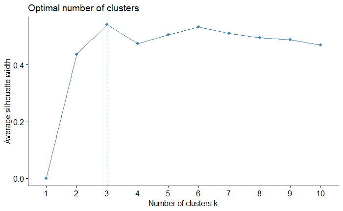

```r
fnb
```

Aplicamos el clustering con kmeans para k=3.

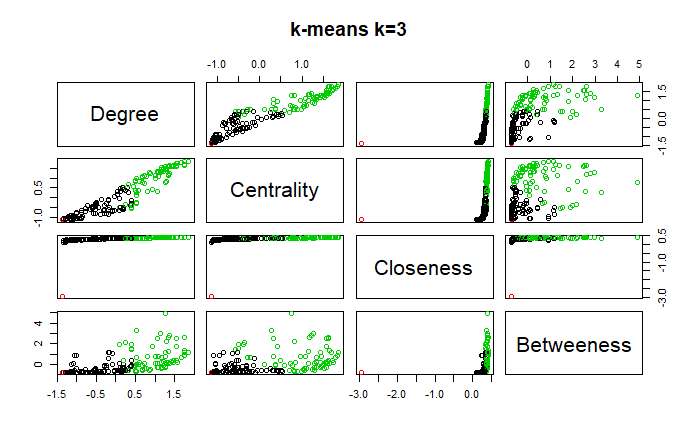

```r
km_grafo <- kmeans(grafodf, centers = 3, nstart = 20)

#visualización
plot(grafodf, col= km_grafo$cluster, main="k-means k=3")
```

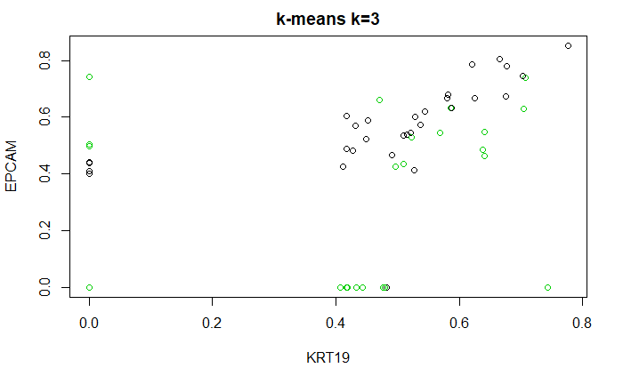

```r
plot(matgraf, col= km_grafo$cluster, main="k-means k=3")
```

Se observan las características del conjunto de datos.

```r
summary(km_grafo)
```

```
             Length Class  Mode
cluster      177    -none- numeric
centers       12    -none- numeric
totss          1    -none- numeric
withinss       3    -none- numeric
tot.withinss   1    -none- numeric
betweenss      1    -none- numeric
size           3    -none- numeric
iter           1    -none- numeric
ifault         1    -none- numeric
```

Estudiamos cada cluster por separado.

```r
km_clusteres <- km_grafo$cluster
kmclust <- data.frame(nodos, km_clusteres)

c1 <- filter(kmclust, kmclust$km_clusteres == 1)
c1
```

| NODOS | km_clusteres |
| --- | --- |
| TACSTD2 | 1 |
| MAL2 | 1 |
| AGR2 | 1 |
| GJA1 | 1 |
| SRGN | 1 |
| UCHL1 | 1 |
| S100P | 1 |
| MIR205HG | 1 |
| BASP1 | 1 |
| SPINT2 | 1 |

[output cut: 78 more lines]

```r
c2 <- filter(kmclust, kmclust$km_clusteres == 2)
c2
```

| NODOS | km_clusteres |
| --- | --- |
| SPP1 | 2 |
| ALDH1A1 | 2 |
| RPS4Y1 | 2 |
| HSPA1A | 2 |
| PLAC8 | 2 |
| MEST | 2 |
| C3orf14 | 2 |
| LXN | 2 |
| CA2 | 2 |
| CRIP1 | 2 |

[output cut: 8 more lines]

```r
c3 <- filter(kmclust, kmclust$km_clusteres == 3)
c3
```

| NODOS | km_clusteres |
| --- | --- |
| KRT19 | 3 |
| EPCAM | 3 |
| TGFBI | 3 |
| VIM | 3 |
| IGFBP7 | 3 |
| CAV1 | 3 |
| DKK1 | 3 |
| C19orf33 | 3 |
| SPARC | 3 |
| TFPI2 | 3 |

[output cut: 61 more lines]

CLUSTERING JERÁRQUICO: Matriz de adyacencia.

Observamos el numero óptimo de clusters.

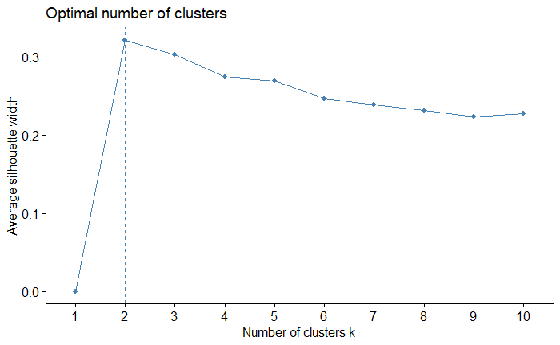

```r
fnv<- fviz_nbclust(matgraf, hcut, method = "silhouette")
fnv
```

Obtengo la matriz de distancias y el dendograma.

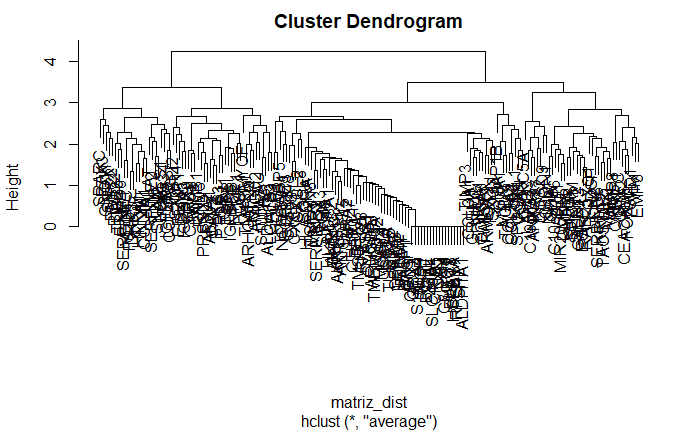

```r
#1- matriz de distancias con dist
matriz_dist <- dist(matgraf)
#2- hclust para construir dendograma
hclust_aux <- hclust(matriz_dist, method = "average")
plot(hclust_aux)
```

Corto el dendograma para k = 2

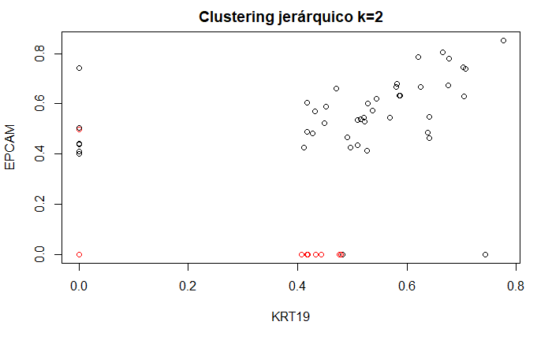

```r
#3- cortar el dendograma y obtener clusters con cutree
grupos1 <- cutree(hclust_aux, k=2)

#represento los resultados
plot(matgraf, col=grupos1, main = "Clustering jerárquico k=2")
```

Se observan las características de los datos generados.

```r
summary(grupos1)
```

```
   Min. 1st Qu.  Median    Mean 3rd Qu.    Max.
  1.000   1.000   1.000   1.322   2.000   2.000
```

Se estudian los clusteres por separado.

```r
hjclust <- data.frame(nodos, grupos1)

c1 <- filter(hjclust, hjclust$grupos1 == 1)
c1
```

| NODOS | grupos1 |
| --- | --- |
| KRT19 | 1 |
| EPCAM | 1 |
| TACSTD2 | 1 |
| MAL2 | 1 |
| AGR2 | 1 |
| VIM | 1 |
| GJA1 | 1 |
| SRGN | 1 |
| SPP1 | 1 |
| C19orf33 | 1 |

[output cut: 110 more lines]

```r
c2 <- filter(hjclust, hjclust$grupos1 == 2)
c2
```

| NODOS | grupos1 |
| --- | --- |
| TGFBI | 2 |
| IGFBP7 | 2 |
| CAV1 | 2 |
| DKK1 | 2 |
| SPARC | 2 |
| TFPI2 | 2 |
| CTGF | 2 |
| IGFBP3 | 2 |
| FSTL1 | 2 |
| ANXA1 | 2 |

[output cut: 47 more lines]

CLUSTERING JERÁRQUICO: Dataframe.

Observamos el numero óptimo de clusters.

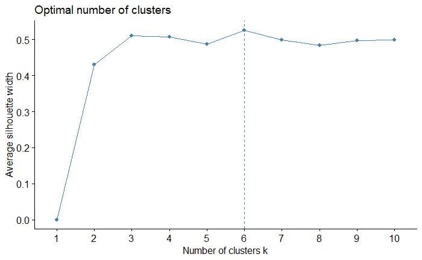

```r
fnv<- fviz_nbclust(grafodf, hcut, method = "silhouette")
fnv
```

```r
fnv$data
```

| clusters | y |
| --- | --- |
| 1 | 0.0000000 |
| 2 | 0.4306172 |
| 3 | 0.5113019 |
| 4 | 0.5072325 |
| 5 | 0.4875760 |
| 6 | 0.5252427 |
| 7 | 0.4982499 |
| 8 | 0.4830149 |
| 9 | 0.4979177 |
| 10 | 0.4987942 |

Obtengo la matriz de distancias y el dendograma.

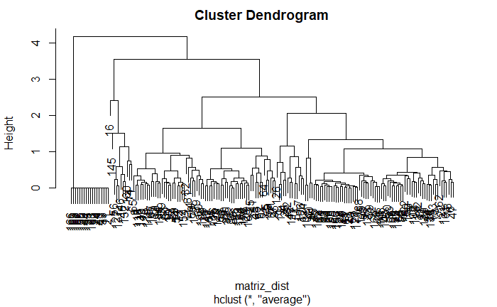

```r
#1- matriz de distancias con dist
matriz_dist <- dist(grafodf)
#2- hclust para construir dendograma
hclust_aux <- hclust(matriz_dist, method = "average")
plot(hclust_aux)
```

Corto el dendograma para k = 6

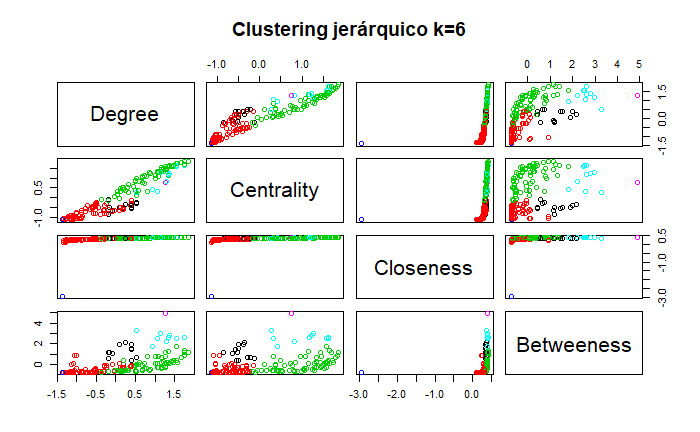

```r
#3- cortar el dendograma y obtener clusters con cutree
grupos1 <- cutree(hclust_aux, k=6)

#represento los resultados
plot(grafodf, col=grupos1, main = "Clustering jerárquico k=6")
```

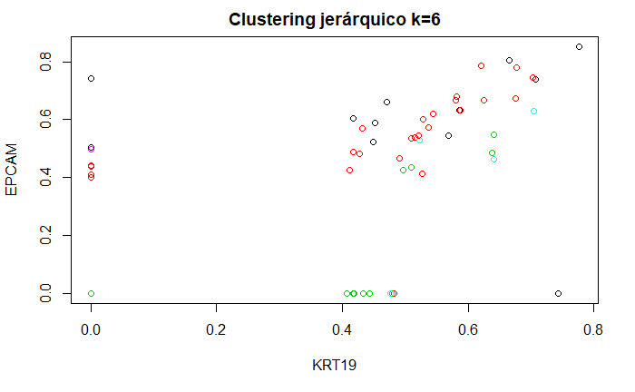

```r
plot(matgraf, col=grupos1, main = "Clustering jerárquico k=6")
```

Se observan las características de los datos generados.

```r
summary(grupos1)
```

```
   Min. 1st Qu.  Median    Mean 3rd Qu.    Max.
  1.000   2.000   4.000   3.294   4.000   6.000
```

Se estudian los clusteres por separado.

```r
hjclust <- data.frame(nodos, grupos1)

c1 <- filter(hjclust, hjclust$grupos1 == 1)
c1
```

| NODOS | grupos1 |
| --- | --- |
| KRT19 | 1 |
| EPCAM | 1 |
| TACSTD2 | 1 |
| MAL2 | 1 |
| AGR2 | 1 |
| VIM | 1 |
| S100P | 1 |
| DSP | 1 |
| MIR205HG | 1 |
| SPINT2 | 1 |

[output cut: 20 more lines]

```r
c2 <- filter(hjclust, hjclust$grupos1 == 2)
c2
```

| NODOS | grupos1 |
| --- | --- |
| TGFBI | 2 |
| CAV1 | 2 |
| DKK1 | 2 |
| TFPI2 | 2 |
| IGFBP3 | 2 |
| ANXA1 | 2 |
| TM4SF1 | 2 |
| AMIGO2 | 2 |
| CAV2 | 2 |
| S100A2 | 2 |

[output cut: 23 more lines]

```r
c3 <- filter(hjclust, hjclust$grupos1 == 3)
c3
```

| NODOS | grupos1 |
| --- | --- |
| GJA1 | 3 |
| COL1A2 | 3 |
| COL5A2 | 3 |
| SPOCK1 | 3 |
| VCAN | 3 |
| MYL9 | 3 |
| LOXL1 | 3 |
| TAGLN | 3 |
| MAP1B | 3 |

```r
c4 <- filter(hjclust, hjclust$grupos1 == 4)
c4
```

| NODOS | grupos1 |
| --- | --- |
| SRGN | 4 |
| SPP1 | 4 |
| UCHL1 | 4 |
| ALDH1A1 | 4 |
| BASP1 | 4 |
| AKR1C3 | 4 |
| MGST1 | 4 |
| AKR1C2 | 4 |
| RPS4Y1 | 4 |
| IFI27 | 4 |

[output cut: 63 more lines]

```r
c5 <- filter(hjclust, hjclust$grupos1 == 5)
c5
```

| NODOS | grupos1 |
| --- | --- |
| IGFBP7 | 5 |
| SPARC | 5 |
| CTGF | 5 |
| FSTL1 | 5 |
| NNMT | 5 |
| SRPX | 5 |
| SERPINE1 | 5 |
| GNG11 | 5 |
| PLAT | 5 |
| TNC | 5 |

[output cut: 14 more lines]

```r
c6 <- filter(hjclust, hjclust$grupos1 == 6)
c6
```

| NODOS | grupos1 |
| --- | --- |
| C19orf33 | 6 |
| ANXA3 | 6 |
| KRT7 | 6 |
| GPRC5A | 6 |
| CD9 | 6 |
| LAMB3 | 6 |
| DSG2 | 6 |
| CLDN1 | 6 |

COMPARACIÓN DE CLÚSTERES Y COMUNIDADES.

Represento gráficamente las comunidades del descubrimiento de comunidades usando la forma de matriz de distancias para poder comparar con estos resultados.

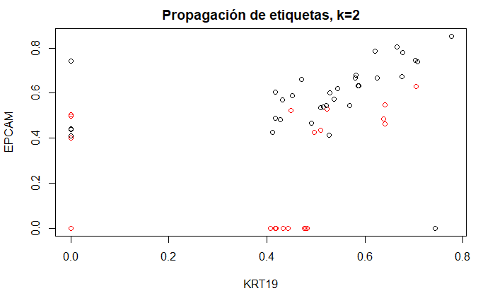

```r
set.seed(55)
inicio<-sample(c(0:176), size = 177, replace = TRUE)
clp <- cluster_label_prop(grafo, initial = inicio)
plot(matgraf, col= clp$membership, main="Propagación de etiquetas, k=2")
```

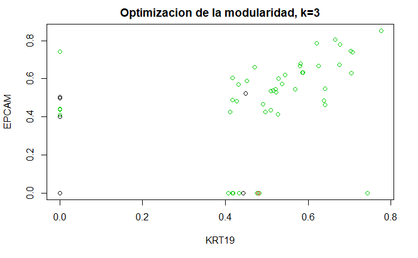

```r
cfg <- cluster_fast_greedy(grafo)
plot(matgraf, col= cfg$membership, main="Optimizacion de la modularidad, k=3")
```